## MA2102

# Probability and Statistics

#### Lecture-20

In general , probability distribution of $k-$ dimensional random vector $\underline{X}\equiv(X_1,X_2,...,X_k)$ is a function $P^{\underline{X}}:\mathscr{B}_k\to \mathbb{R}$,

$P^{\underline{X}}(B)=P(\underline{X}\in B)=P(\{\omega\in\Omega:(X_1(\omega),X_2(\omega),...,X_k(\omega))\in B\})$ for $B\in \mathscr{B}_k$

Here $P^{\underline{X}}$ will satisfies three axioms of probability.And $P^{\underline{X}}$ is called probability distribution of $k-$ dimensional random vector $\underline{X}\equiv(X_1,X_2,...,X_k)$

$JCDF$ of $\underline{X}\equiv(X_1,X_2,...,X_k)$ is defined similarly, $F_{\underline{X}}:\mathbb{R}^k\to\mathbb{R}$

$F_{\underline{X}}(x_1,x_2,...,x_k)=P(X_1\le x_1,X_2\le x_2,...,X_k \le x_k)$

**Properties of $JCDF$:**

- $F_{\underline{X}}(x_1,x_2,...,x_k)$ is non-decreasing right continuous function with respect to each $x_i$(keep other fixed ) for $i=1,2,...,k$
- $lim_{x_i\to\infty\forall i=1,2,..k}F_{\underline{X}}(x_1,x_2,...,x_k)=1$, $lim_{x_i\to -\infty\text{ for some } i=1,2,..k}F_{\underline{X}}(x_1,x_2,...,x_k)=0$

For discrete random vector $\underline{X}=(X_1,X_2,...,X_k)$,  
$S_\underline{X}=\{(x_1,x_2,...,x_k)\in \mathbb{R}^k :P(X_1=x_1,X_2=x_2,...,X_k=x_k)>0\}$ will be support of $\underline{X}$

$JPMF$ of discrete random vector $\underline{X}=(X_1,X_2,...,X_k)$ is $p_{\underline{X}}(x_1,x_2,...,x_k)=P(X_1=x_1,X_2=x_2,...,X_k=x_k)$

$JPMF$ $p_{\underline{X}}:\mathbb{R}^k\to\mathbb{R}$  
$p_{\underline{X}}(x_1,x_2,...,x_k)=\left\{\begin{matrix} P(X_1=x_1,X_2=x_2,...,X_k=x_k) & \text{if }(x_1,x_2,...,x_k)\in S_\underline{X} \\ &\\ 0 & \text{otherwise} \end{matrix}\right.$

**Properties of $JPMF$:**

- $p_\underline{X}(x_1,x_2,...,x_k)\ge 0$
- $\underset{(x_1,x_2,...,x_k)\in S_{\underline{X}}}{\sum }p_{\underline{X}}(x_1,x_2,...,x_k)=1$

For $B\in \mathscr{B}_k$, $P(\underline{X}\in B)=\underset{(x_1,x_2,...,x_k)\in S_{\underline{X}}\cap B}{\sum}p_{\underline{X}}(x_1,x_2,...,x_k)$

For $1\le i_1<i_2<..<i_r\le k$, $JPMF$ of discrete random vector $(X_{i_1},X_{i_2},...,X_{i_r})$ is,

$p_{X_{i_1},X_{i_2},...,X_{i_r}}(x_{i_1},x_{i_2},...,x_{i_r})=\underset{x_{i_{r+1}}\in S_{X_{i_{r+1}}}}{\sum}\underset{x_{i_{r+2}}\in S_{X_{i_{r+2}}}}{\sum}...\underset{x_{i_{k}}\in S_{X_{i_{k}}}}{\sum}p_{\underline{X}}(x_1,x_2,...,x_k)$

Conditional $JPMF$ of $(X_{i_{r+1}},X_{i_{r+2}},...,X_{i_n})$ given that $X_{i_{1}}=x_{i_{1}},X_{i_{2}}=x_{i_{2}},...,X_{i_r}=x_{i_r}$ is  
$p_{{(X_{i_{r+1}},X_{i_{r+2}},...,X_{i_n})}/{(X_{i_1},X_{i_2},...,X_{i_r})}}\left((x_{i_{r+1}},x_{i_{r+2}},...,x_{i_n})/(x_{i_1},x_{i_2},...,x_{i_r})\right)=\frac{p_{\underline{X}}(x_1,x_2,...,x_k)}{p_{X_{i_1},X_{i_2},...,X_{i_r}}(x_{i_1},x_{i_2},...,x_{i_r})}$

where $\{i_1,i_2,i_3,...,i_k\}=\{1,2,3,...,k\}$

$JPDF$ of continuous random vector $\underline{X}=(X_1,X_2,...,X_k)$ is a non-negative function $f_{\underline{X}}(x_1,x_2,...,x_k)$ such that $F_{\underline{X}}(x_1,x_2,...,x_k)=\int_{-\infty}^{x_1}\int_{-\infty}^{x_2}...\int_{-\infty}^{x_k}f_{\underline{X}}(t_1,t_2,...,t_k)dt_1dt_2...dt_k$

and if $f_{\underline{X}}$ is continuous at $(x_1,x_2,...,x_k)$ then $\frac{\partial^kF_{\underline{X}(x_1,x_2,...,x_k)}}{\partial x_1 \partial x_2 ...\partial x_k}=f_{\underline{X}}(x_1,x_2,...,x_k)$

**Properties of $JPDF$:**

- $f_{\underline{X}}(x_1,x_2,...,x_k)\ge 0$
- $\int_{-\infty}^{\infty}\int_{-\infty}^{\infty}...\int_{-\infty}^{\infty}f_{\underline{X}}(x_1,x_2,...,x_k)dx_1dx_2...dx_k=1$

For $B\in \mathscr{B}_k$, $P(\underline{X}\in B)=\underset{B}{\int\int...\int}f_{\underline{X}}(x_1,x_2,...,x_k)dx_1dx_2...dx_k$

For $1\le i_1<i_2<..<i_r\le k$, $JPDF$ of random vector $(X_{i_1},X_{i_2},...,X_{i_r})$ is,

$f_{X_{i_1},X_{i_2},...,X_{i_r}}(x_{i_1},x_{i_2},...,x_{i_r})=\int_{-\infty}^{\infty}\int_{-\infty}^{\infty}...\int_{-\infty}^{\infty}f_{\underline{X}}(x_1,x_2,...,x_k)dx_{i_{r+1}}dx_{i_{r+2}}...dx_{i_{k}}$

Conditional $JPDF$ of $(X_{i_{r+1}},X_{i_{r+2}},...,X_{i_k})$ given that $X_{i_{1}}=x_{i_{1}},X_{i_{2}}=x_{i_{2}},...,X_{i_r}=x_{i_r}$ is  
$f_{{(X_{i_{r+1}},X_{i_{r+2}},...,X_{i_k})}/{(X_{i_1},X_{i_2},...,X_{i_r})}}\left((x_{i_{r+1}},x_{i_{r+2}},...,x_{i_k})/(x_{i_1},x_{i_2},...,x_{i_r})\right)=\frac{f_{\underline{X}}(x_1,x_2,...,x_k)}{f_{X_{i_1},X_{i_2},...,X_{i_r}}(x_{i_1},x_{i_2},...,x_{i_r})}$

where $\{i_1,i_2,i_3,...,i_k\}=\{1,2,3,...,k\}$

## Independent Random Variables:

Let $X,Y$ are two random variables defined on probability space $(\Omega,\mathscr{F},P)$. We say $X,Y$ are independent if $P((X,Y)\in B_1\times B_2)=P(X\in B_1)P(Y\in B_2)$ $\forall~B_1,B_2\in\mathscr{B}$

Intuitively we say $X,Y$ are independent if events that are expressed in terms of $X$ are independent of events expressed in terms of $Y$.

Equivalently we can say $X,Y$ are independent if $F_{X,Y}(x,y)=F_X(x)F_Y(y)~\forall~(x,y)\in\mathbb{R}^2$

i.e Joint $CDF$ is product of marginal $CDF$'s

- If $X,Y$ are discrete (continuous), then we can say $X,Y$ are independent if $p_{X,Y}(x,y)=p_X(x)p_Y(y)$ ($f_{X,Y}(x,y)=f_X(x)f_Y(y)$) $~\forall~(x,y)\in \mathbb{R}^2$

We say k-random variables $X_1,X_2,...,X_k$ defined on probability space $(\Omega,\mathscr{F},P)$ are said to be independent, if  
$F_{\underline{X}}(x_1,x_2,...,x_k)=\prod_{i=1}^kF_{X_i}(x_i)$ $\forall (x_1,x_2,...,x_k)\in \mathbb{R}^k$

Further if $X_1,X_2,...,X_k$ are discrete type then we can also say that $X_1,X_2,...,X_k$ are independent if  
$p_{\underline{X}}(x_1,x_2,...,x_k)=\prod_{i=1}^kp_{X_i}(x_i)$ $\forall (x_1,x_2,...,x_k)\in \mathbb{R}^k$

if $X_1,X_2,...,X_k$ are continuous type then we can also say that $X_1,X_2,...,X_k$ are independent if  
$f_{\underline{X}}(x_1,x_2,...,x_k)=\prod_{i=1}^kf_{X_i}(x_i)$ $\forall (x_1,x_2,...,x_k)\in \mathbb{R}^k$

Where $\underline{X}=(X_1,X_2,...,X_k)$

**Example:** Let $X,Y$ are two continuous random variables with $JPDF$ $f_{X,Y}(x,y)=\left\{\begin{matrix} ye^{-(x+y)}& x>0, y>0 \\ 0& \text{otherwise} \end{matrix}\right.$

then marginal $PDF$'s of $X,Y$ are,

$f_X(x)=\int_{-\infty}^{\infty}f_{X,Y}(x,y)dy=\int_{0}^{\infty}ye^{-(x+y)}dy=e^{-x}\int_{0}^{\infty}y^{2-1}e^{-y}dy=e^{-x}\Gamma(2)=e^{-x}1!$

$f_X(x)=\left\{\begin{matrix} e^{-x}&x>0 \\ 0&x\le 0 \end{matrix}\right.$

$f_Y(y)=\int_{-\infty}^{\infty}f_{X,Y}(x,y)dx=\int_{0}^{\infty}ye^{-(x+y)}dx=ye^{-y}\int_{0}^{\infty}e^{-x}dx=ye^{-y}\Gamma(1)$

$f_Y(y)=\left\{\begin{matrix} ye^{-y}&y>0 \\ 0&y\le 0 \end{matrix}\right.$

here we can see that $f_{X,Y}(x,y)=f_X(x)f_Y(y)$

$\therefore$ $X,Y$ are independent random variables.

**Example:** Let $X,Y$ are two continuous random variables with $JPDF$ $f_{X,Y}(x,y)=\left\{\begin{matrix} 10xy^2& 0<x<y<1 \\ 0& \text{otherwise} \end{matrix}\right.$

$f_X(x)=\left\{\begin{matrix} \frac{10}{3}x(1-x^3)& 0<x<1 \\ 0&\text{otherwise} \end{matrix}\right.$

$f_Y(y)=\left\{\begin{matrix} 5y^4& 0<y<1 \\ 0&\text{otherwise} \end{matrix}\right.$

Here can see that $f_{X,Y}(x,y)\ne f_X(x)f_Y(y)$

$\therefore$ $X,Y$ are not independent random variables.

**Example:** Let $X,Y$ are discrete random variable with $JPMF$

| i \ j | 0 | 1 | $p_X(i)$ |
| --- | --- | --- | --- |
| **0** | $\frac{1}{4}$ | $\frac{1}{4}$ | $\frac{1}{2}$ |
| **1** | $\frac{1}{4}$ | $\frac{1}{4}$ | $\frac{1}{2}$ |
| **$p_{Y}(j)$** | $\frac{1}{2}$ | $\frac{1}{2}$ | $1$ |

Here we can see that $p_{X,Y}(i,j)=p_X(i)p_Y(j)$ $\forall i,j$

$\therefore$ $X,Y$ are independent

**Note:**

- If $X,Y$ are independent discrete random variable, then $p_{X/Y}(i/j)=p_X(i)$, and $p_{Y/X}(j/i)=p_Y(j)$
- If $X,Y$ are independent continuous random variable, then $f_{X/Y}(x/y)=f_X(x)$, and $f_{Y/X}(y/x)=f_Y(y)$

### Expectation:

Let $g:\mathbb{R}^2\to\mathbb{R}$ be function of two variable, and  
If $(X,Y)$ is discrete bivariate random variable with $JPMF$ $p_{X,Y}$ then  
$E(g(X,Y))=\underset{(i,j)\in S_{X,Y}}{\underset{i}{\sum}\underset{j}{\sum}}g(i,j)p_{X,Y}(i,j)$ provided right hand side sum converges absolutely.

If $(X,Y)$ is continuous bivariate random variable with $JPDF$ $f_{X,Y}$ then  
$E(g(X,Y))=\int_{-\infty}^{\infty}\int_{-\infty}^{\infty}g(x,y)f_{X,Y}(x,y)dxdy$ provided right hand side integral converges absolutely.

In general, Let $g:\mathbb{R}^k\to\mathbb{R}$ be function of $k$ variable, and  
If $\underline{X}\equiv(X_1,X_2,...,X_k)$ is discrete $k-$ dimensional random vector with $JPMF$ $p_{\underline{X}}$ then  
$E(g(X_1,X_2,...,X_k))=\underset{(i_1,i_2,...,i_k)\in S_{\underline{X}}}{\underset{i_1}{\sum}\underset{i_2}{\sum}}...{\underset{i_k}{\sum}}~g(i_1,i_2,...,i_k)p_{\underline{X}}(i_1,i_2,...,i_k)$ provided right hand side sum converges absolutely.

If $\underline{X}\equiv(X_1,X_2,...,X_k)$ is continuous $k-$ dimensional random vector with $JPDF$ $f_{\underline{X}}$ then  
$E(g(X_1,X_2,...,X_k))=\int_{-\infty}^{\infty}\int_{-\infty}^{\infty}...\int_{-\infty}^{\infty}~g(x_1,x_2,...,x_k)f_{\underline{X}}(x_1,x_2,...,x_k)dx_1dx_2...dx_k$ provided right hand side integral converges absolutely.

**Theorem:** If $E(g_1(X,Y))$,$E(g_2(X,Y))$ exists, then $E(k_1g_1(X,Y)+k_2g_2(X,Y))$ exists for all $k_1,k_2\in \mathbb{R}$, and  
$E(k_1g_1(X,Y)+k_2g_2(X,Y))=k_1E(g_1(X,Y))+k_2 E(g_2(X,Y))$

*proof:* Here $\int_{-\infty}^{\infty}\int_{-\infty}^{\infty}|g_1(x,y)|f_{X,Y}(x,y)dxdy<\infty$ and $\int_{-\infty}^{\infty}\int_{-\infty}^{\infty}|g_2(x,y)|f_{X,Y}(x,y)dxdy<\infty$

$\int_{-\infty}^{\infty}\int_{-\infty}^{\infty}|k_1g_1(x,y)+k_2g_2(x,y)|f_{X,Y}(x,y)dxdy$

$\le\int_{-\infty}^{\infty}\int_{-\infty}^{\infty}\left(|k_1||g_1(x,y)|+|k_2||g_2(x,y)|\right)f_{X,Y}(x,y)dxdy$

$=|k_1|\int_{-\infty}^{\infty}\int_{-\infty}^{\infty}|g_1(x,y)|f_{X,Y}(x,y)dxdy + |k_2|\int_{-\infty}^{\infty}\int_{-\infty}^{\infty}|g_2(x,y)|f_{X,Y}(x,y)dxdy<\infty$

$\therefore E(k_1g_1(X,Y)+k_2g_2(X,Y))$ exists

$E(k_1g_1(X,Y)+k_2g_2(X,Y)=\int_{-\infty}^{\infty}\int_{-\infty}^{\infty}\left(k_1g_1(x,y)+k_2g_2(x,y)\right)f_{X,Y}(x,y)dxdy$

$= k_1\int_{-\infty}^{\infty}\int_{-\infty}^{\infty}g_1(x,y)f_{X,Y}(x,y)dxdy+k_2\int_{-\infty}^{\infty}\int_{-\infty}^{\infty}g_2(x,y)f_{X,Y}(x,y)dxdy$

$E(k_1g_1(X,Y)+k_2g_2(X,Y)=k_1E(g_1(X,Y))+k_2 E(g_2(X,Y))$

**Corollary 1:** (Linearity of Expectation) If $E(g_i(X,Y))$ exists, for $i=1,2,...,n$, then  
$E\left(\sum_{i=1}^{n}k_ig_i(X,Y)\right)$ exists and $E\left(\sum_{i=1}^{n}k_ig_i(X,Y)\right)=\sum_{i=1}^{n}k_iE(g_i(X,Y))$

**Corollary 2:** Let $(X,Y)$ be Bivariate random variable with both $E(X),E(Y)$ exists,then $E(aX+bY)$ exists, and $E(aX+bY)=aE(X)+bE(Y)$

**Corollary 3:** (Linearity of Expectation)Let $\underline{X}\equiv(X_1,X_2,...,X_k)$ and $E(g_i(\underline{X}))$ exists, for $i=1,2,...,n$, then  
$E\left(\sum_{i=1}^{n}k_ig_i(\underline{X})\right)$ exists and $E\left(\sum_{i=1}^{n}k_ig_i(\underline{X})\right)=\sum_{i=1}^{n}k_iE(g_i(\underline{X}))$

**Corollary 4:** Let $\underline{X}=(X_1,X_2,...,X_k)$ be a random vector with $E(X_i)$ exists for $i=1,2,...,k$ , then $E\left(\sum_{i=1}^{k}a_iX_i\right)$ exists and then $E\left(\sum_{i=1}^{k}a_iX_i\right)=\sum_{i=1}^{k}a_iE(X_i)$

**Theorem:** If $X,Y$ are independent random variables, then for any functions $g,h:\mathbb{R}\to \mathbb{R}$ , then $E(g(X)h(Y))=E(g(X))E(h(Y))$

*proof:* We will prove it by assuming $X,Y$ are jointly continuous random variables.

Since $X,Y$ are independent, we have $f_{X,Y}(x,y)=f_X(x)f_Y(y)$

$E(g(X)h(Y))=\int_{-\infty}^{\infty}\int_{-\infty}^{\infty}g(x)h(y)f_{X,Y}(x,y)dxdy$

$=\int_{-\infty}^{\infty}\int_{-\infty}^{\infty}g(x)h(y)f_X(x)f_Y(y)dxdy$

$=\int_{-\infty}^{\infty}g(x)f_X(x)dx\int_{-\infty}^{\infty}h(y)f_Y(y)dy=E(g(X))E(h(Y))$

**Corollary:** If $X,Y$ are independent then $E(XY)=E(X)E(Y)$

*proof:* $g(X)=X,h(Y)=Y$ in the above theorem

### Cauchy-Schwarz inequality

**Theorem:** Let $(X,Y)$ be a bivariate random variable, then $\left(E(XY)\right)^2\le E(X^2)E(Y^2)$

*proof:* for $t\in \mathbb{R}$ Consider $E((tX+Y)^2)>0 $ (unless $P(Y=-tX)=1$, in which case inequality holds with equality)

$E(t^2X^2+2tXY+Y^2)> 0\implies t^2E(X^2)+2tE(XY)+E(Y^2)> 0$ ---------(1)

(1) is a qudratic inequation in $t$, and $t^2E(X^2)+2tE(XY)+E(Y^2)> 0~~\forall t\in \mathbb{R}$

so $\Delta=(2E(XY))^2-4(E(X^2))(E(Y^2))< 0$

$4(E(XY))^2-4(E(X^2))(E(Y^2))< 0$

$(E(XY))^2<(E(X^2))(E(Y^2))$

$\therefore$ $\left(E(XY)\right)^2\le E(X^2)E(Y^2)$

**Product Moments:**

$\mu_{r,s}^{'}=E(X^r Y^s)$ $\leftarrow$ $(r,s)^{th}$ non-central product moment

$\mu_{1,1}^{'}=E(XY)$, $\mu_{1,0}^{'}=E(X)=\mu_X$, and $\mu_{0,1}^{'}=E(Y)=\mu_Y$

$\mu_{r,s}=E((X-\mu_X)^r (Y-\mu_Y)^s)$ $\leftarrow$ $(r,s)^{th}$ central product moment

$\mu_{1,1}=E((X-\mu_X)(Y-\mu_Y))$

**Definition:** The *Covariance* between $X,Y$ denoted by $Cov(X,Y)$, and it is defined by $Cov(X,Y)=E((X-E(X))(Y-E(Y)))$

**Note:**

1. $Cov(X,Y)=E((X-E(X))(Y-E(Y)))$

$=E\left[XY-XE(Y)-E(X)Y+E(X)E(Y)\right]$

$=E(XY)-E(X)E(Y)-E(X)E(Y)+E(X)E(Y)$ ($\because$ Linear property of expectation)

$$Cov(X,Y)=E(XY)-E(X)E(Y)$$

$Cov(X,Y)$ is also denoted by $\sigma_{XY}$

1. If $X,Y$ are independent then $Cov(X,Y)=0$ ($\because E(XY)=E(X)E(Y)$ when $X,Y$ are independent)

but converse is not true.

Here is the counter example:

Let $X\sim N(0,1)$, $Y=X^2$

As we can see $Y$ is not independent of $X$, and

$E(X)=0$, $E(X^2)=Var(X)+(E(X))^2=1+0^2=1$

$Cov(X,Y)=E(XY)-E(X)E(Y)$

$Cov(X,Y)=E(X^3)-E(X)E(X^2)=0-(0)1=0$ ($\because E(X^{2k+1})=0$ for $X\sim N(0,1)$)

Here $Cov(X,Y)=0$ but $X,Y$ are not independent.

**Theorem:** Let $(X,Y)$ be bivariate random variable then

i. $Cov(X,Y)=Cov(Y,X)$

ii. $Cov(X,X)=Var(X)$

iii. $Cov(X+a,Y+b)=Cov(X,Y)$

iv. $Cov(aX,bY)=abCov(X,Y)$

*proof:* Immediately follow from the definition of covariance

**Theorem:** Let $X_1,X_2,...,X_n$, and $Y_1,Y_2,...,Y_m$ are random variables defined on probability space $(\Omega,\mathscr{F},P)$, then

$Cov(\sum_{i=1}^{n}X_i,\sum_{j=1}^{m}Y_j)=\sum_{i=1}^{n}\sum_{j=1}^{m}Cov(X_i,Y_j)$

*proof:* $Cov(\sum_{i=1}^{n}X_i,\sum_{j=1}^{m}Y_j)=E\left(\left(\sum_{i=1}^{n}X_i-E\left(\sum_{i=1}^{n}X_i\right)\right) \left(\sum_{j=1}^{m}Y_j-E\left(\sum_{j=1}^{m}Y_j\right)\right)\right)$ ($\because$ definition of covariance)

$=E\left(\left(\sum_{i=1}^{n}X_i-\sum_{i=1}^{n}E(X_i)\right) \left(\sum_{j=1}^{m}Y_j-\sum_{j=1}^{m}E(Y_j)\right)\right)$ ($\because$ linearity of expectation)

$=E\left(\sum_{i=1}^{n}\sum_{j=1}^{n}(X_i-E(X_i))(Y_j-E(Y_j))\right)$

$=\sum_{i=1}^{n}\sum_{j=1}^{m}E\left((X_i-E(X_i))(Y_j-E(Y_j))\right)$

$Cov(\sum_{i=1}^{n}X_i,\sum_{j=1}^{m}Y_j)=\sum_{i=1}^{n}\sum_{j=1}^{m}Cov(X_i,Y_j)$

**Corollary:** $Cov(\sum_{i=1}^{n}a_iX_i,\sum_{j=1}^{m}b_jY_j)=\sum_{i=1}^{n}\sum_{j=1}^{m}a_ib_jCov(X_i,Y_j)$

**Theorem:** Let $X_1,X_2,...,X_n$ are $n$ random variables defined on $(\Omega,\mathscr{F},P)$, then  
$Var(\sum_{i=1}^{n}a_iX_i)=\sum_{i=1}^{n}a_i^2Var(X_i)+2\sum_{i=1}^{n}\sum_{j=1}^{n}a_ia_jCov(X_i,X_j)$

*proof:* $Var(\sum_{i=1}^{n}a_iX_i)=Cov\left(\sum_{i=1}^{n}a_iX_i,\sum_{j=1}^{n}a_jX_j\right)$ ($\because$$Var(X)=Cov(X,X)$)

$=\sum_{i=1}^{n}\sum_{j=1}^{n}a_ia_jCov(X_i,X_j)$

$=\sum_{i=1}^{n}a_i^2Cov(X_i,X_i)+\underset{i\ne j}{\sum_{i=1}^{n}\sum_{j=1}^{n}}a_ia_jCov(X_i,X_j)$

$=\sum_{i=1}^{n}a_i^2Var(X_i)+2\underset{i< j}{\sum_{i=1}^{n}\sum_{j=1}^{n}}a_ia_jCov(X_i,X_j)$ ($\because$$Cov(X,Y)=Cov(Y,X)$)

$Var(\sum_{i=1}^{n}a_iX_i)=\sum_{i=1}^{n}a_i^2Var(X_i)+2\sum_{i=1}^{n}\sum_{j=1}^{n}a_ia_jCov(X_i,X_j)$

**Corollary:**  
1. $Var(X\pm Y)=Var(X)+Var(Y)\pm 2Cov(X,Y)$

1. If $X_1,X_2,...,X_n$ are independent random variables then we have $Cov(X_i,X_j)=0$ for $i\ne j$  
   $Var(\sum_{i=1}^{n}a_iX_i)=\sum_{i=1}^{n}a_i^2Var(X_i)$
1. If $X,Y$ are independent random variables then $Var(X\pm Y)=Var(X)+Var(Y)$

### Correlation Coefficient:

The *Correlation coefficient* between two random variables $X,Y$ is denoted by $\rho_{XY}$ and defined as,

$$\rho_{XY}=\frac{Cov(X,Y)}{SD(X)\times SD(Y)}$$

In terms of $\sigma$ notation we can write as $\rho_{X,Y}=\frac{\sigma_{XY}}{\sigma_X\sigma_Y}$

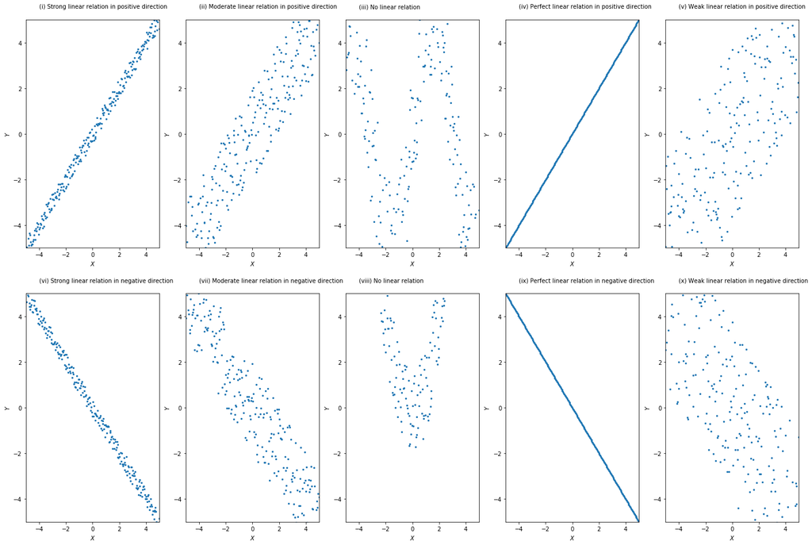

```python
import random as rd
import numpy as np
import matplotlib.pyplot as plt
%matplotlib inline

fig, ax = plt.subplots(2,5,figsize=(24, 16))
x=np.linspace(-5,5,250)
fns=[
[lambda x:x+np.random.uniform(-0.4,0.4,len(x)),
lambda x:x+np.random.uniform(-2,2,len(x)),
lambda x:5*np.sin(x)+np.random.uniform(-3,3,len(x)),
lambda x:x,
lambda x:x+np.random.uniform(-4,4,len(x)), ],

[lambda x:-x+np.random.uniform(-0.4,0.4,len(x)),
lambda x:-x+np.random.uniform(-2,2,len(x)),
lambda x:x*x+np.random.uniform(-2,2,len(x)),
lambda x:-x,
lambda x:-x+np.random.uniform(-4,4,len(x)),]
]
msgs=[
    ["(i) Strong linear relation in positive direction",
     "(ii) Moderate linear relation in positive direction",
     "(iii) No linear relation",
     "(iv) Perfect linear relation in positive direction",
      "(v) Weak linear relation in positive direction",
    ],
    ["(vi) Strong linear relation in negative direction",
     "(vii) Moderate linear relation in negative direction",
     "(viii) No linear relation",
     "(ix) Perfect linear relation in negative direction",
       "(x) Weak linear relation in negative direction"
    ]
]


for i in [0,1]:
    for j in [0,1,2,3,4]:
        ax[i][j].scatter(x,fns[i][j](x),s=5)
        ax[i][j].set_xlim(-5,5)
        ax[i][j].set_ylim(-5,5)
        ax[i][j].text(-4,5.5,msgs[i][j])
        ax[i][j].set_xlabel(r"$X$")
        ax[i][j].set_ylabel(r"$Y$")
plt.show()
```

**Theorem:** For any two random variables $X,Y$ defined on $(\Omega,\mathscr{F},P)$, $-1\le \rho_{XY}\le 1$

*proof:* By Cauchy-Schwarz inequality we have

$(E((X-\mu_X)(Y-\mu_Y)))^2\le E((X-\mu_X)^2)E((Y-\mu_Y)^2)$

$(E((X-\mu_X)(Y-\mu_Y)))^2\le \sigma_X^2 \sigma_Y^2$

$|E((X-\mu_X)(Y-\mu_Y))|\le \sigma_X \sigma_Y$

$\begin{vmatrix}\frac{E((X-\mu_X)(Y-\mu_Y))}{\sigma_X \sigma_Y} \end{vmatrix} \le 1 $

$-1\le \frac{E((X-\mu_X)(Y-\mu_Y))}{\sigma_X \sigma_Y}\le 1$

$\therefore$ $-1\le \rho_{XY} \le 1$

In Cauchy-Schwarz inequality we have, both sides equality if $P((Y-\mu_Y)=-t(X-\mu_X))=1$ (please have a look at proof of Cauchy-Schwarz inequality)

**Case-1**: $\rho_{XY} = 1$

$\frac{E((X-\mu_X)(Y-\mu_Y))}{\sigma_X \sigma_Y} = 1$

$\frac{E((X-\mu_X)(-t(X-\mu_X)))}{\sigma_X \sigma_Y}= 1$

$(-t)\frac{\sigma_X^2}{\sigma_X \sigma_Y}= 1\implies t=-\frac{\sigma_Y}{\sigma_X}$

$\therefore~P\left((Y-\mu_Y)=-\left(\frac{-\sigma_Y}{\sigma_X}\right)(X-\mu_X)\right)=1$

$P\left(Y=\left(\frac{\sigma_Y}{\sigma_X}\right)X-\left(\frac{\sigma_Y}{\sigma_X}\right)\mu_X+\mu_Y\right)=1$

$P\left(Y=aX+b\right)=1$ where $a=\frac{\sigma_Y}{\sigma_X}>0, b=\mu_Y -\frac{\sigma_Y}{\sigma_X}\mu_X$

**Case-2**: $\rho_{XY} = -1$

$\frac{E((X-\mu_X)(Y-\mu_Y))}{\sigma_X \sigma_Y} = -1$

$\frac{E((X-\mu_X)(-t(X-\mu_X)))}{\sigma_X \sigma_Y}= -1$

$t\frac{\sigma_X^2}{\sigma_X \sigma_Y}= 1\implies t=\frac{\sigma_Y}{\sigma_X}$

$\therefore~P\left((Y-\mu_Y)=-\left(\frac{\sigma_Y}{\sigma_X}\right)(X-\mu_X)\right)=1$

$P\left(Y=\left(-\frac{\sigma_Y}{\sigma_X}\right)X+\left(\frac{\sigma_Y}{\sigma_X}\right)\mu_X+\mu_Y\right)=1$

- $X$ & $Y$ are perfectly linearly related in positive direction if $P(X=aY+b)=1$ for some $a,b\in \mathbb{R}$ and $a>0$
- $X$ & $Y$ are perfectly linearly related in negative direction if $P(X=aY+b)=1$ for some $a,b\in \mathbb{R}$ and $a<0$

The *correlation coefficient* is a measure of the degree of linear relation between $X$ and $Y$.

A value of $\rho_{XY}$ near $1$ or $-1$ indicates a high degree of linear relation between $X$ and $Y$. whereas a value near $0$ indicates a lack of such linear relation.

A positive $\rho_{XY}$ value indicates $Y$ tends to increase when $X$ does, whereas a negative value indicates that $Y$ tends to decrease when $X$ increases

- If $\rho_{XY}=0$, then $X,Y$ are said to be uncorrelated.

If $X,Y$ are independent then they are uncorrelated but converse is not true.

$X\sim N(0,1)$,$Y=X^2$, then $\rho_{XY}=0$ ($\because~Cov(X,Y)=0$) but $X,Y$ are dependent)

Here there is no linear relationship between $X,Y$ but we do have non-linear relationship between $X,Y$

**Problem:** Let $(X,Y)$ be a continuous bivariate random variable with $f_{X,Y}(x,y)=\left\{\begin{matrix} x+y&0<x<1,0<y<1 \\ 0& \text{otherwise} \end{matrix}\right.$  
Find $\rho_{XY}$

*solution:* $\rho_{XY}=\frac{Cov(X,Y)}{\sigma_X\sigma_Y}$, here $Cov(X,Y)=E(XY)-E(X)E(Y)$

$f_X(x)=\int_{-\infty}^{\infty}f_{X,Y}(x,y)dy=\int_{0}^{1}(x+y)dy=\left[xy+\frac{y^2}{2}\right]_{0}^1=(x+\frac{1}{2})-0$

$f_X(x)=\left\{\begin{matrix} x+\frac{1}{2}&0<x<1 \\ 0& \text{otherwise} \end{matrix}\right.$

and $f_Y(y)=\left\{\begin{matrix} y+\frac{1}{2}&0<y<1 \\ 0&\text{otherwise} \end{matrix}\right.$ ($\because~$ Symmetry in $x,y$)

$E(XY)=\int_{-\infty}^{\infty}\int_{-\infty}^{\infty}xyf_{X,Y}(x,y)dxdy=\int_{0}^{1}\int_{0}^{1}xy(x+y)dxdy=\frac{1}{3}$ (please work out this double integral)

$E(X)=\int_{-\infty}^{\infty}xf_X(x)dx=\int_{0}^{1}x(x+\frac{1}{2})dx=\frac{7}{12}$ and $E(Y)=\frac{7}{12}$

$E(X^2)=\int_{-\infty}^{\infty}x^2f_X(x)dx=\int_{0}^{1}x^2(x+\frac{1}{2})dx=\frac{5}{12}$ and $E(Y^2)=\frac{5}{12}$

$\sigma_X^2=E(X^2)-(E(X))^2=\frac{5}{12}-\left(\frac{7}{12}\right)^2=\frac{11}{144}$, and $\sigma_Y^2=\frac{11}{144}$

$\sigma_X=\sigma_Y=\frac{\sqrt{11}}{12}$

$Cov(X,Y)=E(XY)-E(X)E(Y)=\frac{1}{3}-\left(\frac{7}{12}\right)\left(\frac{7}{12}\right)=\frac{-1}{144}$

$\rho_{X,Y}=\frac{Cov(X,Y)}{\sigma_X\sigma_Y}=\frac{\frac{-1}{144}}{\frac{\sqrt{11}}{12}\frac{\sqrt{11}}{12}}=\frac{-1}{11}$

**Problem:** Let $(X,Y)$ be a continuous bivariate random variable with $f_{X,Y}(x,y)=\left\{\begin{matrix} 2&0<y<x<1 \\ 0& \text{otherwise} \end{matrix}\right.$.  
Find $Var(3X-2Y)$

```
(0, 2)
```

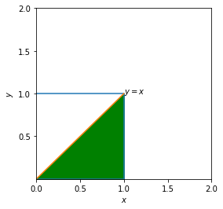

```python
import numpy as np
import matplotlib.pyplot as plt
%matplotlib inline

fig, ax = plt.subplots(figsize=(4,4))
ax.plot([0,1,1,0],[0,0,1,1])
ax.plot([0,1],[0,1])
x=np.linspace(0,1,100)
ax.fill_between(x,0,x,color='g')
ax.set_xlabel("$x$")
ax.set_ylabel("$y$")
ax.text(1,1,"$y=x$")
ax.set_xticks([0.0,0.5,1,1.5,2])
ax.set_yticks([0.5,1,1.5,2])
ax.set_xlim(0,2)
ax.set_ylim(0,2)
```

$Var(3X-2Y)=(3)^2Var(X)+(-2)^2Var(Y)+2(3)(-2)Cov(X,Y)=9Var(X)+4Var(Y)-12Cov(X,Y)$

$f_X(x)=\int_{-\infty}^{\infty}f_{X,Y}(x,y)dy=\int_{0}^{x}2dy=2x$

$f_X(x)=\left\{\begin{matrix} 2x& 0<x<1 \\ 0& \text{otherwise} \end{matrix}\right.$

$f_Y(y)=\int_{-\infty}^{\infty}f_{X,Y}(x,y)dx=\int_{y}^{1}2dx=2(1-y)$

$f_Y(y)=\left\{\begin{matrix} 2(1-y)& 0<y<1 \\ 0& \text{otherwise} \end{matrix}\right.$

$E(XY)=\int_{-\infty}^{\infty}\int_{-\infty}^{\infty}xyf_{X,Y}(x,y)dxdy=\int_{0}^{1}\int_{0}^{x}xy(2)dydx$

$=2\int_{0}^{1}x\int_{0}^{x}ydydx=2\int_{0}^{1}x\left[\frac{y^2}{2}\right]_0^x dx=\frac{1}{4}$

$E(X)=\int_{0}^{1}x(2x)dx=\frac{2}{3}$

$E(X^2)=\int_{0}^{1}x^2(2x)dx=\frac{1}{2}$

$E(Y)=\int_{0}^{1}y(2(1-y))dy=\frac{1}{3}$

$E(Y^2)=\int_{0}^{1}y^2(2(1-y))dy=\frac{1}{6}$

$Var(X)=E(X^2)-(E(X))^2=\frac{1}{2}-\left(\frac{2}{3}\right)^2=\frac{1}{18}$

$Var(Y)=E(Y^2)-(E(Y))^2=\frac{1}{6}-\left(\frac{1}{3}\right)^2=\frac{1}{18}$

$Cov(X,Y)=E(XY)-E(X)E(Y)=\frac{1}{4}-\left(\frac{2}{3}\right)\left(\frac{1}{3}\right)=\frac{1}{36}$

$Var(3X-2Y)=9\left(\frac{1}{18}\right)+4\left(\frac{1}{18}\right)-12\left(\frac{1}{36}\right)=\frac{7}{18}$